# Risk Factor Analysis

## Outcome Variable

**Outcome Variable:** pers_wast

## Predictor Variables

**Intervention Variable:** hhwealth_quart

**Adjustment Set:**

unadjusted

## Stratifying Variables

The analysis was stratified on these variable(s):

- agecat
- studyid
- country

## Data Summary

| agecat | studyid | country | hhwealth_quart | pers_wast | n_cell | n |
| --- | --- | --- | --- | --- | --- | --- |
| 0-24 months | ki0047075b-MAL-ED | BANGLADESH | Wealth Q4 | 0 | 20 | 82 |
| 0-24 months | ki0047075b-MAL-ED | BANGLADESH | Wealth Q4 | 1 | 1 | 82 |
| 0-24 months | ki0047075b-MAL-ED | BANGLADESH | Wealth Q1 | 0 | 20 | 82 |
| 0-24 months | ki0047075b-MAL-ED | BANGLADESH | Wealth Q1 | 1 | 1 | 82 |
| 0-24 months | ki0047075b-MAL-ED | BANGLADESH | Wealth Q2 | 0 | 19 | 82 |
| 0-24 months | ki0047075b-MAL-ED | BANGLADESH | Wealth Q2 | 1 | 1 | 82 |
| 0-24 months | ki0047075b-MAL-ED | BANGLADESH | Wealth Q3 | 0 | 18 | 82 |
| 0-24 months | ki0047075b-MAL-ED | BANGLADESH | Wealth Q3 | 1 | 2 | 82 |
| 0-24 months | ki0047075b-MAL-ED | INDIA | Wealth Q4 | 0 | 16 | 71 |
| 0-24 months | ki0047075b-MAL-ED | INDIA | Wealth Q4 | 1 | 2 | 71 |
| 0-24 months | ki0047075b-MAL-ED | INDIA | Wealth Q1 | 0 | 16 | 71 |
| 0-24 months | ki0047075b-MAL-ED | INDIA | Wealth Q1 | 1 | 3 | 71 |
| 0-24 months | ki0047075b-MAL-ED | INDIA | Wealth Q2 | 0 | 15 | 71 |
| 0-24 months | ki0047075b-MAL-ED | INDIA | Wealth Q2 | 1 | 2 | 71 |
| 0-24 months | ki0047075b-MAL-ED | INDIA | Wealth Q3 | 0 | 17 | 71 |
| 0-24 months | ki0047075b-MAL-ED | INDIA | Wealth Q3 | 1 | 0 | 71 |
| 0-24 months | ki0047075b-MAL-ED | NEPAL | Wealth Q4 | 0 | 11 | 42 |
| 0-24 months | ki0047075b-MAL-ED | NEPAL | Wealth Q4 | 1 | 0 | 42 |
| 0-24 months | ki0047075b-MAL-ED | NEPAL | Wealth Q1 | 0 | 11 | 42 |
| 0-24 months | ki0047075b-MAL-ED | NEPAL | Wealth Q1 | 1 | 0 | 42 |
| 0-24 months | ki0047075b-MAL-ED | NEPAL | Wealth Q2 | 0 | 10 | 42 |
| 0-24 months | ki0047075b-MAL-ED | NEPAL | Wealth Q2 | 1 | 0 | 42 |
| 0-24 months | ki0047075b-MAL-ED | NEPAL | Wealth Q3 | 0 | 10 | 42 |
| 0-24 months | ki0047075b-MAL-ED | NEPAL | Wealth Q3 | 1 | 0 | 42 |
| 0-24 months | ki0047075b-MAL-ED | PERU | Wealth Q4 | 0 | 10 | 36 |
| 0-24 months | ki0047075b-MAL-ED | PERU | Wealth Q4 | 1 | 0 | 36 |
| 0-24 months | ki0047075b-MAL-ED | PERU | Wealth Q1 | 0 | 9 | 36 |
| 0-24 months | ki0047075b-MAL-ED | PERU | Wealth Q1 | 1 | 0 | 36 |
| 0-24 months | ki0047075b-MAL-ED | PERU | Wealth Q2 | 0 | 8 | 36 |
| 0-24 months | ki0047075b-MAL-ED | PERU | Wealth Q2 | 1 | 0 | 36 |

[output cut: 330 more lines]

The following strata were considered:

- agecat: 0-24 months, studyid: ki0047075b-MAL-ED, country: BANGLADESH
- agecat: 0-24 months, studyid: ki0047075b-MAL-ED, country: INDIA
- agecat: 0-24 months, studyid: ki0047075b-MAL-ED, country: NEPAL
- agecat: 0-24 months, studyid: ki0047075b-MAL-ED, country: PERU
- agecat: 0-24 months, studyid: ki0047075b-MAL-ED, country: SOUTH AFRICA
- agecat: 0-24 months, studyid: ki0047075b-MAL-ED, country: TANZANIA, UNITED REPUBLIC OF
- agecat: 0-24 months, studyid: ki1000108-CMC-V-BCS-2002, country: INDIA
- agecat: 0-24 months, studyid: ki1000108-IRC, country: INDIA
- agecat: 0-24 months, studyid: ki1017093b-PROVIDE, country: BANGLADESH
- agecat: 0-24 months, studyid: ki1066203-TanzaniaChild2, country: TANZANIA, UNITED REPUBLIC OF
- agecat: 0-24 months, studyid: ki1113344-GMS-Nepal, country: NEPAL
- agecat: 0-24 months, studyid: ki1114097-CONTENT, country: PERU
- agecat: 0-24 months, studyid: ki1135781-COHORTS, country: GUATEMALA
- agecat: 0-24 months, studyid: ki1135781-COHORTS, country: PHILIPPINES
- agecat: 0-24 months, studyid: ki1148112-LCNI-5, country: MALAWI
- agecat: 0-24 months, studyid: kiGH5241-JiVitA-3, country: BANGLADESH
- agecat: 0-24 months, studyid: kiGH5241-JiVitA-4, country: BANGLADESH
- agecat: 0-6 months, studyid: ki0047075b-MAL-ED, country: BANGLADESH
- agecat: 0-6 months, studyid: ki0047075b-MAL-ED, country: INDIA
- agecat: 0-6 months, studyid: ki0047075b-MAL-ED, country: NEPAL
- agecat: 0-6 months, studyid: ki0047075b-MAL-ED, country: PERU
- agecat: 0-6 months, studyid: ki0047075b-MAL-ED, country: SOUTH AFRICA
- agecat: 0-6 months, studyid: ki0047075b-MAL-ED, country: TANZANIA, UNITED REPUBLIC OF
- agecat: 0-6 months, studyid: ki1000108-CMC-V-BCS-2002, country: INDIA
- agecat: 0-6 months, studyid: ki1000108-IRC, country: INDIA
- agecat: 0-6 months, studyid: ki1017093b-PROVIDE, country: BANGLADESH
- agecat: 0-6 months, studyid: ki1066203-TanzaniaChild2, country: TANZANIA, UNITED REPUBLIC OF
- agecat: 0-6 months, studyid: ki1113344-GMS-Nepal, country: NEPAL
- agecat: 0-6 months, studyid: ki1114097-CONTENT, country: PERU
- agecat: 6-24 months, studyid: ki0047075b-MAL-ED, country: BANGLADESH
- agecat: 6-24 months, studyid: ki0047075b-MAL-ED, country: INDIA
- agecat: 6-24 months, studyid: ki0047075b-MAL-ED, country: NEPAL
- agecat: 6-24 months, studyid: ki0047075b-MAL-ED, country: PERU
- agecat: 6-24 months, studyid: ki0047075b-MAL-ED, country: SOUTH AFRICA
- agecat: 6-24 months, studyid: ki0047075b-MAL-ED, country: TANZANIA, UNITED REPUBLIC OF
- agecat: 6-24 months, studyid: ki1000108-CMC-V-BCS-2002, country: INDIA
- agecat: 6-24 months, studyid: ki1000108-IRC, country: INDIA
- agecat: 6-24 months, studyid: ki1017093b-PROVIDE, country: BANGLADESH
- agecat: 6-24 months, studyid: ki1066203-TanzaniaChild2, country: TANZANIA, UNITED REPUBLIC OF
- agecat: 6-24 months, studyid: ki1113344-GMS-Nepal, country: NEPAL
- agecat: 6-24 months, studyid: ki1114097-CONTENT, country: PERU
- agecat: 6-24 months, studyid: ki1135781-COHORTS, country: GUATEMALA
- agecat: 6-24 months, studyid: ki1135781-COHORTS, country: PHILIPPINES
- agecat: 6-24 months, studyid: ki1148112-LCNI-5, country: MALAWI
- agecat: 6-24 months, studyid: kiGH5241-JiVitA-4, country: BANGLADESH

### Dropped Strata

Some strata were dropped due to rare outcomes:

- agecat: 0-24 months, studyid: ki0047075b-MAL-ED, country: BANGLADESH
- agecat: 0-24 months, studyid: ki0047075b-MAL-ED, country: INDIA
- agecat: 0-24 months, studyid: ki0047075b-MAL-ED, country: NEPAL
- agecat: 0-24 months, studyid: ki0047075b-MAL-ED, country: PERU
- agecat: 0-24 months, studyid: ki0047075b-MAL-ED, country: SOUTH AFRICA
- agecat: 0-24 months, studyid: ki0047075b-MAL-ED, country: TANZANIA, UNITED REPUBLIC OF
- agecat: 0-24 months, studyid: ki1000108-CMC-V-BCS-2002, country: INDIA
- agecat: 0-24 months, studyid: ki1017093b-PROVIDE, country: BANGLADESH
- agecat: 0-24 months, studyid: ki1114097-CONTENT, country: PERU
- agecat: 0-24 months, studyid: ki1135781-COHORTS, country: GUATEMALA
- agecat: 0-24 months, studyid: ki1148112-LCNI-5, country: MALAWI
- agecat: 0-6 months, studyid: ki0047075b-MAL-ED, country: BANGLADESH
- agecat: 0-6 months, studyid: ki0047075b-MAL-ED, country: INDIA
- agecat: 0-6 months, studyid: ki0047075b-MAL-ED, country: NEPAL
- agecat: 0-6 months, studyid: ki0047075b-MAL-ED, country: PERU
- agecat: 0-6 months, studyid: ki0047075b-MAL-ED, country: SOUTH AFRICA
- agecat: 0-6 months, studyid: ki0047075b-MAL-ED, country: TANZANIA, UNITED REPUBLIC OF
- agecat: 0-6 months, studyid: ki1017093b-PROVIDE, country: BANGLADESH
- agecat: 0-6 months, studyid: ki1114097-CONTENT, country: PERU
- agecat: 6-24 months, studyid: ki0047075b-MAL-ED, country: BANGLADESH
- agecat: 6-24 months, studyid: ki0047075b-MAL-ED, country: INDIA
- agecat: 6-24 months, studyid: ki0047075b-MAL-ED, country: NEPAL
- agecat: 6-24 months, studyid: ki0047075b-MAL-ED, country: PERU
- agecat: 6-24 months, studyid: ki0047075b-MAL-ED, country: SOUTH AFRICA
- agecat: 6-24 months, studyid: ki0047075b-MAL-ED, country: TANZANIA, UNITED REPUBLIC OF
- agecat: 6-24 months, studyid: ki1000108-CMC-V-BCS-2002, country: INDIA
- agecat: 6-24 months, studyid: ki1017093b-PROVIDE, country: BANGLADESH
- agecat: 6-24 months, studyid: ki1114097-CONTENT, country: PERU
- agecat: 6-24 months, studyid: ki1148112-LCNI-5, country: MALAWI

## Methods Detail

We’re interested in the causal parameters $E[Y_a]$ for all values of $a \in \mathcal{A}$. These parameters represent the mean outcome if, possibly contrary to fact, we intervened to set all units to have $A=a$. Under the randomization and positivity assumptions, these are identified by the statistical parameters $\psi_a=E_W[E_{Y|A,W}(Y|A=a,W)]$. In addition, we’re interested in the mean of $Y$, $E[Y]$ under no intervention (the observed mean). We will estimate these parameters by using SuperLearner to fit the relevant likelihood factors – $E_{Y|A,W}(Y|A=a,W)$ and $p(A=a|W)$, and then updating our likelihood fit using a joint TMLE.

For unadjusted analyses ($W=\{\}$), initial likelihoods were estimated using Lrnr_glm to estimate the simple $E(Y|A)$ and Lrnr_mean to estimate $p(A)$. For adjusted analyses, a small library containing Lrnr_glmnet, Lrnr_xgboost, and Lrnr_mean was used.

Having estimated these parameters, we will then use the delta method to estimate relative risks and attributable risks relative to a prespecified baseline level of $A$.

# Results Detail

## Results Plots

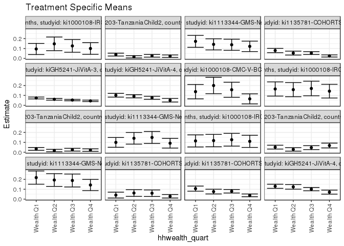

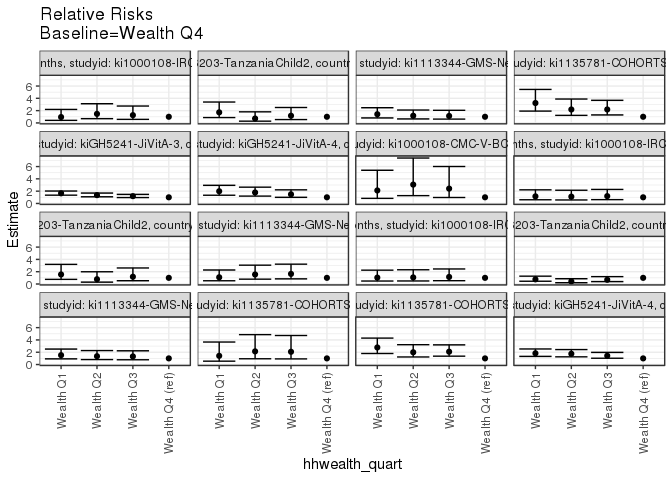

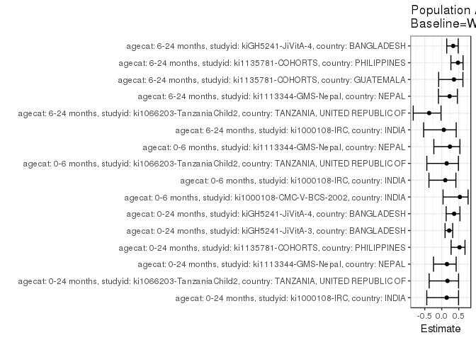

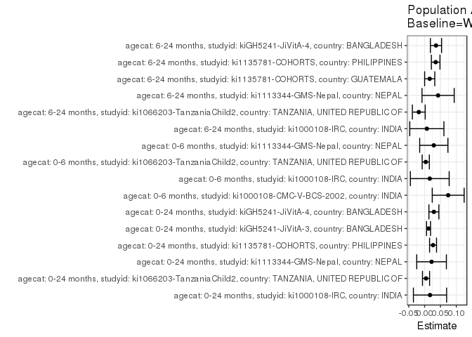

## Results Table

### Parameter: TSM

| agecat | studyid | country | intervention_level | baseline_level | estimate | ci_lower | ci_upper |
| --- | --- | --- | --- | --- | --- | --- | --- |
| 0-24 months | ki1000108-IRC | INDIA | Wealth Q4 | NA | 0.1000000 | 0.0411292 | 0.1588708 |
| 0-24 months | ki1000108-IRC | INDIA | Wealth Q1 | NA | 0.0952381 | 0.0390226 | 0.1514536 |
| 0-24 months | ki1000108-IRC | INDIA | Wealth Q2 | NA | 0.1470588 | 0.0782438 | 0.2158739 |
| 0-24 months | ki1000108-IRC | INDIA | Wealth Q3 | NA | 0.1262136 | 0.0620017 | 0.1904255 |
| 0-24 months | ki1066203-TanzaniaChild2 | TANZANIA, UNITED REPUBLIC OF | Wealth Q4 | NA | 0.0223881 | 0.0098607 | 0.0349154 |
| 0-24 months | ki1066203-TanzaniaChild2 | TANZANIA, UNITED REPUBLIC OF | Wealth Q1 | NA | 0.0385208 | 0.0237112 | 0.0533304 |
| 0-24 months | ki1066203-TanzaniaChild2 | TANZANIA, UNITED REPUBLIC OF | Wealth Q2 | NA | 0.0160183 | 0.0042447 | 0.0277919 |
| 0-24 months | ki1066203-TanzaniaChild2 | TANZANIA, UNITED REPUBLIC OF | Wealth Q3 | NA | 0.0261682 | 0.0126381 | 0.0396983 |
| 0-24 months | ki1113344-GMS-Nepal | NEPAL | Wealth Q4 | NA | 0.1216216 | 0.0689192 | 0.1743240 |
| 0-24 months | ki1113344-GMS-Nepal | NEPAL | Wealth Q1 | NA | 0.1721854 | 0.1119168 | 0.2324541 |
| 0-24 months | ki1113344-GMS-Nepal | NEPAL | Wealth Q2 | NA | 0.1418919 | 0.0856274 | 0.1981563 |
| 0-24 months | ki1113344-GMS-Nepal | NEPAL | Wealth Q3 | NA | 0.1379310 | 0.0817573 | 0.1941048 |
| 0-24 months | ki1135781-COHORTS | PHILIPPINES | Wealth Q4 | NA | 0.0245796 | 0.0136622 | 0.0354969 |
| 0-24 months | ki1135781-COHORTS | PHILIPPINES | Wealth Q1 | NA | 0.0794702 | 0.0578963 | 0.1010441 |
| 0-24 months | ki1135781-COHORTS | PHILIPPINES | Wealth Q2 | NA | 0.0536779 | 0.0339783 | 0.0733776 |
| 0-24 months | ki1135781-COHORTS | PHILIPPINES | Wealth Q3 | NA | 0.0537057 | 0.0392222 | 0.0681892 |
| 0-24 months | kiGH5241-JiVitA-3 | BANGLADESH | Wealth Q4 | NA | 0.0448268 | 0.0372254 | 0.0524282 |
| 0-24 months | kiGH5241-JiVitA-3 | BANGLADESH | Wealth Q1 | NA | 0.0739334 | 0.0644203 | 0.0834465 |
| 0-24 months | kiGH5241-JiVitA-3 | BANGLADESH | Wealth Q2 | NA | 0.0606840 | 0.0521829 | 0.0691851 |
| 0-24 months | kiGH5241-JiVitA-3 | BANGLADESH | Wealth Q3 | NA | 0.0532454 | 0.0461188 | 0.0603721 |
| 0-24 months | kiGH5241-JiVitA-4 | BANGLADESH | Wealth Q4 | NA | 0.0512609 | 0.0332535 | 0.0692682 |
| 0-24 months | kiGH5241-JiVitA-4 | BANGLADESH | Wealth Q1 | NA | 0.1017802 | 0.0829361 | 0.1206243 |
| 0-24 months | kiGH5241-JiVitA-4 | BANGLADESH | Wealth Q2 | NA | 0.0914753 | 0.0752634 | 0.1076872 |
| 0-24 months | kiGH5241-JiVitA-4 | BANGLADESH | Wealth Q3 | NA | 0.0761626 | 0.0612455 | 0.0910797 |
| 0-6 months | ki1000108-CMC-V-BCS-2002 | INDIA | Wealth Q4 | NA | 0.0652174 | 0.0146933 | 0.1157415 |
| 0-6 months | ki1000108-CMC-V-BCS-2002 | INDIA | Wealth Q1 | NA | 0.1379310 | 0.0653709 | 0.2104911 |
| 0-6 months | ki1000108-CMC-V-BCS-2002 | INDIA | Wealth Q2 | NA | 0.2000000 | 0.1172450 | 0.2827550 |
| 0-6 months | ki1000108-CMC-V-BCS-2002 | INDIA | Wealth Q3 | NA | 0.1573034 | 0.0815564 | 0.2330503 |
| 0-6 months | ki1000108-IRC | INDIA | Wealth Q4 | NA | 0.1428571 | 0.0734901 | 0.2122242 |
| 0-6 months | ki1000108-IRC | INDIA | Wealth Q1 | NA | 0.1650485 | 0.0932680 | 0.2368291 |
| 0-6 months | ki1000108-IRC | INDIA | Wealth Q2 | NA | 0.1584158 | 0.0871180 | 0.2297137 |
| 0-6 months | ki1000108-IRC | INDIA | Wealth Q3 | NA | 0.1700000 | 0.0962856 | 0.2437144 |
| 0-6 months | ki1066203-TanzaniaChild2 | TANZANIA, UNITED REPUBLIC OF | Wealth Q4 | NA | 0.0216963 | 0.0090116 | 0.0343809 |
| 0-6 months | ki1066203-TanzaniaChild2 | TANZANIA, UNITED REPUBLIC OF | Wealth Q1 | NA | 0.0337079 | 0.0195326 | 0.0478831 |
| 0-6 months | ki1066203-TanzaniaChild2 | TANZANIA, UNITED REPUBLIC OF | Wealth Q2 | NA | 0.0168675 | 0.0044749 | 0.0292600 |
| 0-6 months | ki1066203-TanzaniaChild2 | TANZANIA, UNITED REPUBLIC OF | Wealth Q3 | NA | 0.0255906 | 0.0118554 | 0.0393257 |
| 0-6 months | ki1113344-GMS-Nepal | NEPAL | Wealth Q4 | NA | 0.0909091 | 0.0418218 | 0.1399964 |
| 0-6 months | ki1113344-GMS-Nepal | NEPAL | Wealth Q1 | NA | 0.0992908 | 0.0498840 | 0.1486975 |
| 0-6 months | ki1113344-GMS-Nepal | NEPAL | Wealth Q2 | NA | 0.1407407 | 0.0820250 | 0.1994564 |
| 0-6 months | ki1113344-GMS-Nepal | NEPAL | Wealth Q3 | NA | 0.1492537 | 0.0888645 | 0.2096429 |
| 6-24 months | ki1000108-IRC | INDIA | Wealth Q4 | NA | 0.1100000 | 0.0485998 | 0.1714002 |
| 6-24 months | ki1000108-IRC | INDIA | Wealth Q1 | NA | 0.1142857 | 0.0533564 | 0.1752151 |
| 6-24 months | ki1000108-IRC | INDIA | Wealth Q2 | NA | 0.1176471 | 0.0550448 | 0.1802493 |
| 6-24 months | ki1000108-IRC | INDIA | Wealth Q3 | NA | 0.1262136 | 0.0620017 | 0.1904255 |
| 6-24 months | ki1066203-TanzaniaChild2 | TANZANIA, UNITED REPUBLIC OF | Wealth Q4 | NA | 0.0677966 | 0.0435439 | 0.0920493 |
| 6-24 months | ki1066203-TanzaniaChild2 | TANZANIA, UNITED REPUBLIC OF | Wealth Q1 | NA | 0.0514851 | 0.0322058 | 0.0707645 |
| 6-24 months | ki1066203-TanzaniaChild2 | TANZANIA, UNITED REPUBLIC OF | Wealth Q2 | NA | 0.0286533 | 0.0111452 | 0.0461613 |
| 6-24 months | ki1066203-TanzaniaChild2 | TANZANIA, UNITED REPUBLIC OF | Wealth Q3 | NA | 0.0464037 | 0.0265384 | 0.0662691 |
| 6-24 months | ki1113344-GMS-Nepal | NEPAL | Wealth Q4 | NA | 0.1428571 | 0.0862406 | 0.1994737 |
| 6-24 months | ki1113344-GMS-Nepal | NEPAL | Wealth Q1 | NA | 0.2176871 | 0.1509184 | 0.2844557 |
| 6-24 months | ki1113344-GMS-Nepal | NEPAL | Wealth Q2 | NA | 0.1931034 | 0.1287985 | 0.2574084 |
| 6-24 months | ki1113344-GMS-Nepal | NEPAL | Wealth Q3 | NA | 0.1884058 | 0.1231075 | 0.2537041 |
| 6-24 months | ki1135781-COHORTS | GUATEMALA | Wealth Q4 | NA | 0.0289017 | 0.0112396 | 0.0465638 |
| 6-24 months | ki1135781-COHORTS | GUATEMALA | Wealth Q1 | NA | 0.0409357 | 0.0112215 | 0.0706498 |
| 6-24 months | ki1135781-COHORTS | GUATEMALA | Wealth Q2 | NA | 0.0618557 | 0.0279392 | 0.0957721 |
| 6-24 months | ki1135781-COHORTS | GUATEMALA | Wealth Q3 | NA | 0.0600000 | 0.0270685 | 0.0929315 |
| 6-24 months | ki1135781-COHORTS | PHILIPPINES | Wealth Q4 | NA | 0.0382514 | 0.0243541 | 0.0521486 |
| 6-24 months | ki1135781-COHORTS | PHILIPPINES | Wealth Q1 | NA | 0.1062271 | 0.0803768 | 0.1320774 |
| 6-24 months | ki1135781-COHORTS | PHILIPPINES | Wealth Q2 | NA | 0.0762712 | 0.0523208 | 0.1002215 |
| 6-24 months | ki1135781-COHORTS | PHILIPPINES | Wealth Q3 | NA | 0.0798650 | 0.0620419 | 0.0976881 |
| 6-24 months | kiGH5241-JiVitA-4 | BANGLADESH | Wealth Q4 | NA | 0.0710264 | 0.0508243 | 0.0912285 |
| 6-24 months | kiGH5241-JiVitA-4 | BANGLADESH | Wealth Q1 | NA | 0.1298860 | 0.1091093 | 0.1506627 |
| 6-24 months | kiGH5241-JiVitA-4 | BANGLADESH | Wealth Q2 | NA | 0.1240342 | 0.1007470 | 0.1473213 |
| 6-24 months | kiGH5241-JiVitA-4 | BANGLADESH | Wealth Q3 | NA | 0.1011022 | 0.0842379 | 0.1179666 |

### Parameter: E(Y)

| agecat | studyid | country | intervention_level | baseline_level | estimate | ci_lower | ci_upper |
| --- | --- | --- | --- | --- | --- | --- | --- |
| 0-24 months | ki1000108-IRC | INDIA | NA | NA | 0.1170732 | 0.0859146 | 0.1482317 |
| 0-24 months | ki1066203-TanzaniaChild2 | TANZANIA, UNITED REPUBLIC OF | NA | NA | 0.0268892 | 0.0200612 | 0.0337172 |
| 0-24 months | ki1113344-GMS-Nepal | NEPAL | NA | NA | 0.1435811 | 0.1153098 | 0.1718524 |
| 0-24 months | ki1135781-COHORTS | PHILIPPINES | NA | NA | 0.0512273 | 0.0430760 | 0.0593786 |
| 0-24 months | kiGH5241-JiVitA-3 | BANGLADESH | NA | NA | 0.0572358 | 0.0531429 | 0.0613287 |
| 0-24 months | kiGH5241-JiVitA-4 | BANGLADESH | NA | NA | 0.0805591 | 0.0719065 | 0.0892117 |
| 0-6 months | ki1000108-CMC-V-BCS-2002 | INDIA | NA | NA | 0.1396648 | 0.1037072 | 0.1756225 |
| 0-6 months | ki1000108-IRC | INDIA | NA | NA | 0.1592040 | 0.1233945 | 0.1950135 |
| 0-6 months | ki1066203-TanzaniaChild2 | TANZANIA, UNITED REPUBLIC OF | NA | NA | 0.0253288 | 0.0185306 | 0.0321270 |
| 0-6 months | ki1113344-GMS-Nepal | NEPAL | NA | NA | 0.1199262 | 0.0925505 | 0.1473020 |
| 6-24 months | ki1000108-IRC | INDIA | NA | NA | 0.1170732 | 0.0859146 | 0.1482317 |
| 6-24 months | ki1066203-TanzaniaChild2 | TANZANIA, UNITED REPUBLIC OF | NA | NA | 0.0494700 | 0.0391528 | 0.0597871 |
| 6-24 months | ki1113344-GMS-Nepal | NEPAL | NA | NA | 0.1854419 | 0.1537023 | 0.2171816 |
| 6-24 months | ki1135781-COHORTS | GUATEMALA | NA | NA | 0.0450055 | 0.0315357 | 0.0584753 |
| 6-24 months | ki1135781-COHORTS | PHILIPPINES | NA | NA | 0.0731338 | 0.0631985 | 0.0830690 |
| 6-24 months | kiGH5241-JiVitA-4 | BANGLADESH | NA | NA | 0.1069508 | 0.0962252 | 0.1176764 |

### Parameter: RR

| agecat | studyid | country | intervention_level | baseline_level | estimate | ci_lower | ci_upper |
| --- | --- | --- | --- | --- | --- | --- | --- |
| 0-24 months | ki1000108-IRC | INDIA | Wealth Q4 | Wealth Q4 | 1.0000000 | 1.0000000 | 1.0000000 |
| 0-24 months | ki1000108-IRC | INDIA | Wealth Q1 | Wealth Q4 | 0.9523810 | 0.4137684 | 2.1921189 |
| 0-24 months | ki1000108-IRC | INDIA | Wealth Q2 | Wealth Q4 | 1.4705882 | 0.6932491 | 3.1195562 |
| 0-24 months | ki1000108-IRC | INDIA | Wealth Q3 | Wealth Q4 | 1.2621359 | 0.5796824 | 2.7480341 |
| 0-24 months | ki1066203-TanzaniaChild2 | TANZANIA, UNITED REPUBLIC OF | Wealth Q4 | Wealth Q4 | 1.0000000 | 1.0000000 | 1.0000000 |
| 0-24 months | ki1066203-TanzaniaChild2 | TANZANIA, UNITED REPUBLIC OF | Wealth Q1 | Wealth Q4 | 1.7205958 | 0.8726409 | 3.3925180 |
| 0-24 months | ki1066203-TanzaniaChild2 | TANZANIA, UNITED REPUBLIC OF | Wealth Q2 | Wealth Q4 | 0.7154845 | 0.2840630 | 1.8021283 |
| 0-24 months | ki1066203-TanzaniaChild2 | TANZANIA, UNITED REPUBLIC OF | Wealth Q3 | Wealth Q4 | 1.1688474 | 0.5456139 | 2.5039760 |
| 0-24 months | ki1113344-GMS-Nepal | NEPAL | Wealth Q4 | Wealth Q4 | 1.0000000 | 1.0000000 | 1.0000000 |
| 0-24 months | ki1113344-GMS-Nepal | NEPAL | Wealth Q1 | Wealth Q4 | 1.4157469 | 0.8110866 | 2.4711779 |
| 0-24 months | ki1113344-GMS-Nepal | NEPAL | Wealth Q2 | Wealth Q4 | 1.1666667 | 0.6484135 | 2.0991407 |
| 0-24 months | ki1113344-GMS-Nepal | NEPAL | Wealth Q3 | Wealth Q4 | 1.1340996 | 0.6257314 | 2.0554856 |
| 0-24 months | ki1135781-COHORTS | PHILIPPINES | Wealth Q4 | Wealth Q4 | 1.0000000 | 1.0000000 | 1.0000000 |
| 0-24 months | ki1135781-COHORTS | PHILIPPINES | Wealth Q1 | Wealth Q4 | 3.2331823 | 1.9211236 | 5.4413303 |
| 0-24 months | ki1135781-COHORTS | PHILIPPINES | Wealth Q2 | Wealth Q4 | 2.1838443 | 1.2274252 | 3.8855126 |
| 0-24 months | ki1135781-COHORTS | PHILIPPINES | Wealth Q3 | Wealth Q4 | 2.1849737 | 1.2994972 | 3.6738133 |
| 0-24 months | kiGH5241-JiVitA-3 | BANGLADESH | Wealth Q4 | Wealth Q4 | 1.0000000 | 1.0000000 | 1.0000000 |
| 0-24 months | kiGH5241-JiVitA-3 | BANGLADESH | Wealth Q1 | Wealth Q4 | 1.6493116 | 1.3463850 | 2.0203944 |
| 0-24 months | kiGH5241-JiVitA-3 | BANGLADESH | Wealth Q2 | Wealth Q4 | 1.3537431 | 1.0838524 | 1.6908394 |
| 0-24 months | kiGH5241-JiVitA-3 | BANGLADESH | Wealth Q3 | Wealth Q4 | 1.1878035 | 0.9576037 | 1.4733412 |
| 0-24 months | kiGH5241-JiVitA-4 | BANGLADESH | Wealth Q4 | Wealth Q4 | 1.0000000 | 1.0000000 | 1.0000000 |
| 0-24 months | kiGH5241-JiVitA-4 | BANGLADESH | Wealth Q1 | Wealth Q4 | 1.9855344 | 1.3384210 | 2.9455208 |
| 0-24 months | kiGH5241-JiVitA-4 | BANGLADESH | Wealth Q2 | Wealth Q4 | 1.7845057 | 1.2005701 | 2.6524571 |
| 0-24 months | kiGH5241-JiVitA-4 | BANGLADESH | Wealth Q3 | Wealth Q4 | 1.4857845 | 0.9948829 | 2.2189100 |
| 0-6 months | ki1000108-CMC-V-BCS-2002 | INDIA | Wealth Q4 | Wealth Q4 | 1.0000000 | 1.0000000 | 1.0000000 |
| 0-6 months | ki1000108-CMC-V-BCS-2002 | INDIA | Wealth Q1 | Wealth Q4 | 2.1149425 | 0.8291086 | 5.3949289 |
| 0-6 months | ki1000108-CMC-V-BCS-2002 | INDIA | Wealth Q2 | Wealth Q4 | 3.0666667 | 1.2741917 | 7.3807140 |
| 0-6 months | ki1000108-CMC-V-BCS-2002 | INDIA | Wealth Q3 | Wealth Q4 | 2.4119850 | 0.9687855 | 6.0051185 |
| 0-6 months | ki1000108-IRC | INDIA | Wealth Q4 | Wealth Q4 | 1.0000000 | 1.0000000 | 1.0000000 |
| 0-6 months | ki1000108-IRC | INDIA | Wealth Q1 | Wealth Q4 | 1.1553398 | 0.6020198 | 2.2172197 |
| 0-6 months | ki1000108-IRC | INDIA | Wealth Q2 | Wealth Q4 | 1.1089109 | 0.5719560 | 2.1499613 |
| 0-6 months | ki1000108-IRC | INDIA | Wealth Q3 | Wealth Q4 | 1.1900000 | 0.6206144 | 2.2817710 |
| 0-6 months | ki1066203-TanzaniaChild2 | TANZANIA, UNITED REPUBLIC OF | Wealth Q4 | Wealth Q4 | 1.0000000 | 1.0000000 | 1.0000000 |
| 0-6 months | ki1066203-TanzaniaChild2 | TANZANIA, UNITED REPUBLIC OF | Wealth Q1 | Wealth Q4 | 1.5536261 | 0.7560946 | 3.1923971 |
| 0-6 months | ki1066203-TanzaniaChild2 | TANZANIA, UNITED REPUBLIC OF | Wealth Q2 | Wealth Q4 | 0.7774371 | 0.3040121 | 1.9881064 |
| 0-6 months | ki1066203-TanzaniaChild2 | TANZANIA, UNITED REPUBLIC OF | Wealth Q3 | Wealth Q4 | 1.1794918 | 0.5333532 | 2.6084045 |
| 0-6 months | ki1113344-GMS-Nepal | NEPAL | Wealth Q4 | Wealth Q4 | 1.0000000 | 1.0000000 | 1.0000000 |
| 0-6 months | ki1113344-GMS-Nepal | NEPAL | Wealth Q1 | Wealth Q4 | 1.0921985 | 0.5240950 | 2.2761096 |
| 0-6 months | ki1113344-GMS-Nepal | NEPAL | Wealth Q2 | Wealth Q4 | 1.5481480 | 0.7824749 | 3.0630533 |
| 0-6 months | ki1113344-GMS-Nepal | NEPAL | Wealth Q3 | Wealth Q4 | 1.6417909 | 0.8361514 | 3.2236712 |
| 6-24 months | ki1000108-IRC | INDIA | Wealth Q4 | Wealth Q4 | 1.0000000 | 1.0000000 | 1.0000000 |
| 6-24 months | ki1000108-IRC | INDIA | Wealth Q1 | Wealth Q4 | 1.0389610 | 0.4801491 | 2.2481350 |
| 6-24 months | ki1000108-IRC | INDIA | Wealth Q2 | Wealth Q4 | 1.0695187 | 0.4946168 | 2.3126394 |
| 6-24 months | ki1000108-IRC | INDIA | Wealth Q3 | Wealth Q4 | 1.1473963 | 0.5391541 | 2.4418219 |
| 6-24 months | ki1066203-TanzaniaChild2 | TANZANIA, UNITED REPUBLIC OF | Wealth Q4 | Wealth Q4 | 1.0000000 | 1.0000000 | 1.0000000 |
| 6-24 months | ki1066203-TanzaniaChild2 | TANZANIA, UNITED REPUBLIC OF | Wealth Q1 | Wealth Q4 | 0.7594059 | 0.4524435 | 1.2746286 |
| 6-24 months | ki1066203-TanzaniaChild2 | TANZANIA, UNITED REPUBLIC OF | Wealth Q2 | Wealth Q4 | 0.4226361 | 0.2081932 | 0.8579592 |
| 6-24 months | ki1066203-TanzaniaChild2 | TANZANIA, UNITED REPUBLIC OF | Wealth Q3 | Wealth Q4 | 0.6844548 | 0.3917941 | 1.1957258 |
| 6-24 months | ki1113344-GMS-Nepal | NEPAL | Wealth Q4 | Wealth Q4 | 1.0000000 | 1.0000000 | 1.0000000 |
| 6-24 months | ki1113344-GMS-Nepal | NEPAL | Wealth Q1 | Wealth Q4 | 1.5238095 | 0.9231829 | 2.5152064 |
| 6-24 months | ki1113344-GMS-Nepal | NEPAL | Wealth Q2 | Wealth Q4 | 1.3517241 | 0.8055191 | 2.2682990 |
| 6-24 months | ki1113344-GMS-Nepal | NEPAL | Wealth Q3 | Wealth Q4 | 1.3188406 | 0.7790096 | 2.2327588 |
| 6-24 months | ki1135781-COHORTS | GUATEMALA | Wealth Q4 | Wealth Q4 | 1.0000000 | 1.0000000 | 1.0000000 |
| 6-24 months | ki1135781-COHORTS | GUATEMALA | Wealth Q1 | Wealth Q4 | 1.4163743 | 0.5483915 | 3.6581822 |
| 6-24 months | ki1135781-COHORTS | GUATEMALA | Wealth Q2 | Wealth Q4 | 2.1402062 | 0.9416365 | 4.8643850 |
| 6-24 months | ki1135781-COHORTS | GUATEMALA | Wealth Q3 | Wealth Q4 | 2.0760000 | 0.9130568 | 4.7201622 |
| 6-24 months | ki1135781-COHORTS | PHILIPPINES | Wealth Q4 | Wealth Q4 | 1.0000000 | 1.0000000 | 1.0000000 |
| 6-24 months | ki1135781-COHORTS | PHILIPPINES | Wealth Q1 | Wealth Q4 | 2.7770801 | 1.7934078 | 4.3002901 |
| 6-24 months | ki1135781-COHORTS | PHILIPPINES | Wealth Q2 | Wealth Q4 | 1.9939467 | 1.2335604 | 3.2230474 |
| 6-24 months | ki1135781-COHORTS | PHILIPPINES | Wealth Q3 | Wealth Q4 | 2.0878997 | 1.3631233 | 3.1980417 |
| 6-24 months | kiGH5241-JiVitA-4 | BANGLADESH | Wealth Q4 | Wealth Q4 | 1.0000000 | 1.0000000 | 1.0000000 |
| 6-24 months | kiGH5241-JiVitA-4 | BANGLADESH | Wealth Q1 | Wealth Q4 | 1.8286997 | 1.3218809 | 2.5298366 |
| 6-24 months | kiGH5241-JiVitA-4 | BANGLADESH | Wealth Q2 | Wealth Q4 | 1.7463102 | 1.2538674 | 2.4321546 |
| 6-24 months | kiGH5241-JiVitA-4 | BANGLADESH | Wealth Q3 | Wealth Q4 | 1.4234456 | 1.0269021 | 1.9731164 |

### Parameter: PAR

| agecat | studyid | country | intervention_level | baseline_level | estimate | ci_lower | ci_upper |
| --- | --- | --- | --- | --- | --- | --- | --- |
| 0-24 months | ki1000108-IRC | INDIA | Wealth Q4 | NA | 0.0170732 | -0.0353292 | 0.0694755 |
| 0-24 months | ki1066203-TanzaniaChild2 | TANZANIA, UNITED REPUBLIC OF | Wealth Q4 | NA | 0.0045011 | -0.0067043 | 0.0157066 |
| 0-24 months | ki1113344-GMS-Nepal | NEPAL | Wealth Q4 | NA | 0.0219595 | -0.0248170 | 0.0687360 |
| 0-24 months | ki1135781-COHORTS | PHILIPPINES | Wealth Q4 | NA | 0.0266478 | 0.0156896 | 0.0376059 |
| 0-24 months | kiGH5241-JiVitA-3 | BANGLADESH | Wealth Q4 | NA | 0.0124090 | 0.0060982 | 0.0187198 |
| 0-24 months | kiGH5241-JiVitA-4 | BANGLADESH | Wealth Q4 | NA | 0.0292982 | 0.0135968 | 0.0449997 |
| 0-6 months | ki1000108-CMC-V-BCS-2002 | INDIA | Wealth Q4 | NA | 0.0744474 | 0.0241121 | 0.1247827 |
| 0-6 months | ki1000108-IRC | INDIA | Wealth Q4 | NA | 0.0163468 | -0.0448746 | 0.0775683 |
| 0-6 months | ki1066203-TanzaniaChild2 | TANZANIA, UNITED REPUBLIC OF | Wealth Q4 | NA | 0.0036325 | -0.0076655 | 0.0149306 |
| 0-6 months | ki1113344-GMS-Nepal | NEPAL | Wealth Q4 | NA | 0.0290171 | -0.0155400 | 0.0735742 |
| 6-24 months | ki1000108-IRC | INDIA | Wealth Q4 | NA | 0.0070732 | -0.0467954 | 0.0609417 |
| 6-24 months | ki1066203-TanzaniaChild2 | TANZANIA, UNITED REPUBLIC OF | Wealth Q4 | NA | -0.0183266 | -0.0385382 | 0.0018849 |
| 6-24 months | ki1113344-GMS-Nepal | NEPAL | Wealth Q4 | NA | 0.0425848 | -0.0082047 | 0.0933743 |
| 6-24 months | ki1135781-COHORTS | GUATEMALA | Wealth Q4 | NA | 0.0161038 | 0.0000904 | 0.0321171 |
| 6-24 months | ki1135781-COHORTS | PHILIPPINES | Wealth Q4 | NA | 0.0348824 | 0.0212919 | 0.0484729 |
| 6-24 months | kiGH5241-JiVitA-4 | BANGLADESH | Wealth Q4 | NA | 0.0359244 | 0.0182774 | 0.0535713 |

### Parameter: PAF

| agecat | studyid | country | intervention_level | baseline_level | estimate | ci_lower | ci_upper |
| --- | --- | --- | --- | --- | --- | --- | --- |
| 0-24 months | ki1000108-IRC | INDIA | Wealth Q4 | NA | 0.1458333 | -0.4403244 | 0.4934470 |
| 0-24 months | ki1066203-TanzaniaChild2 | TANZANIA, UNITED REPUBLIC OF | Wealth Q4 | NA | 0.1673958 | -0.3700147 | 0.4939983 |
| 0-24 months | ki1113344-GMS-Nepal | NEPAL | Wealth Q4 | NA | 0.1529412 | -0.2428950 | 0.4227118 |
| 0-24 months | ki1135781-COHORTS | PHILIPPINES | Wealth Q4 | NA | 0.5201865 | 0.2748607 | 0.6825148 |
| 0-24 months | kiGH5241-JiVitA-3 | BANGLADESH | Wealth Q4 | NA | 0.2168052 | 0.0967462 | 0.3209062 |
| 0-24 months | kiGH5241-JiVitA-4 | BANGLADESH | Wealth Q4 | NA | 0.3636861 | 0.1298018 | 0.5347090 |
| 0-6 months | ki1000108-CMC-V-BCS-2002 | INDIA | Wealth Q4 | NA | 0.5330435 | 0.0379996 | 0.7733386 |
| 0-6 months | ki1000108-IRC | INDIA | Wealth Q4 | NA | 0.1026786 | -0.3767125 | 0.4151388 |
| 0-6 months | ki1066203-TanzaniaChild2 | TANZANIA, UNITED REPUBLIC OF | Wealth Q4 | NA | 0.1434153 | -0.4391886 | 0.4901729 |
| 0-6 months | ki1113344-GMS-Nepal | NEPAL | Wealth Q4 | NA | 0.2419580 | -0.2321932 | 0.5336545 |
| 6-24 months | ki1000108-IRC | INDIA | Wealth Q4 | NA | 0.0604167 | -0.5329147 | 0.4240927 |
| 6-24 months | ki1066203-TanzaniaChild2 | TANZANIA, UNITED REPUBLIC OF | Wealth Q4 | NA | -0.3704600 | -0.8379702 | -0.0218668 |
| 6-24 months | ki1113344-GMS-Nepal | NEPAL | Wealth Q4 | NA | 0.2296395 | -0.0966331 | 0.4588388 |
| 6-24 months | ki1135781-COHORTS | GUATEMALA | Wealth Q4 | NA | 0.3578176 | -0.0909799 | 0.6219928 |
| 6-24 months | ki1135781-COHORTS | PHILIPPINES | Wealth Q4 | NA | 0.4769671 | 0.2689101 | 0.6258142 |
| 6-24 months | kiGH5241-JiVitA-4 | BANGLADESH | Wealth Q4 | NA | 0.3358962 | 0.1462815 | 0.4833967 |